# Study of Annual Migration Patterns of the Baltimore Oriole

#### Take the mean by month

Gives us the mean number of occurrences in a given month.

```python
# Take the mean by month
mean_occurrences_by_month = (
    occurrence_df
    .groupby('month')
    .mean()
)
mean_occurrences_by_month
```

| month | occurrences | area | density |
| --- | --- | --- | --- |
| 1.0 | 186.096774 | 7.103442 | 119.720622 |
| 2.0 | 167.935484 | 5.971543 | 114.267011 |
| 3.0 | 147.676923 | 5.911391 | 119.012923 |
| 4.0 | 339.815789 | 9.274769 | 57.863214 |
| 5.0 | 4020.181818 | 17.520827 | 324.009395 |
| 6.0 | 1846.558140 | 24.536460 | 149.367654 |
| 7.0 | 731.162162 | 22.870137 | 60.125886 |
| 8.0 | 656.714286 | 19.313669 | 60.287617 |
| 9.0 | 214.259740 | 13.187489 | 46.109531 |
| 10.0 | 149.589041 | 8.409373 | 63.454302 |
| 11.0 | 126.456140 | 8.570266 | 64.232304 |
| 12.0 | 139.112676 | 7.586825 | 63.587655 |

#### Normalize by space and time for sampling effort

The goal of this step is to remove systematic differences such as some months have more sampling efforts because more birdwatchers are outside, and some regions are more heavily surveyed.

The goal of the new column, "norm_occurrences" is to give an occurrence count that is normalized for space and time differences.

```python
# Normalize by space and time for sampling effort
occurrence_df['norm_occurrences'] = (
    occurrence_df[['density']]
    / mean_occurrences_by_ecoregion[['density']]
    / mean_occurrences_by_month[['density']]
)
occurrence_df
```

| ecoregion_id | month | occurrences | area | density | norm_occurrences |
| --- | --- | --- | --- | --- | --- |
| 13.0 | 5.0 | 46 | 17.133639 | 2.684777 | 0.006106 |
|  | 6.0 | 33 | 17.133639 | 1.926036 | 0.009502 |
|  | 7.0 | 9 | 17.133639 | 0.525282 | 0.006438 |
|  | 8.0 | 5 | 17.133639 | 0.291824 | 0.003567 |
| 17.0 | 4.0 | 56 | 7.958751 | 7.036280 | 0.000532 |
| ... | ... | ... | ... | ... | ... |
| 833.0 | 12.0 | 3 | 0.610793 | 4.911644 | 0.010722 |
| 839.0 | 5.0 | 12 | 35.905513 | 0.334211 | 0.001157 |
|  | 6.0 | 79 | 35.905513 | 2.200219 | 0.016528 |
|  | 7.0 | 13 | 35.905513 | 0.362061 | 0.006757 |
|  | 8.0 | 24 | 35.905513 | 0.668421 | 0.012440 |

738 rows × 4 columns

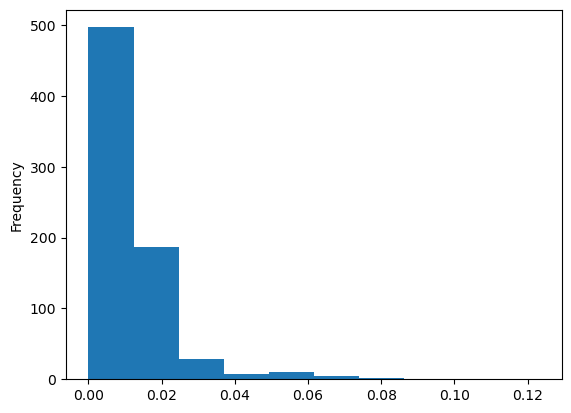

```python
occurrence_df.norm_occurrences.plot.hist()
```

**Figure 1:** This histogram plot shows that there is a higher frequency of normalized ecoregions with low occurrence values, and fewer ecoregions with higher occurrence values.

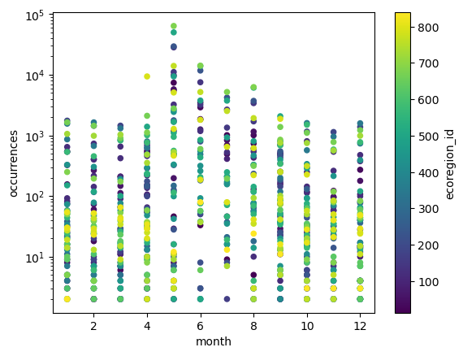

```python
# Plotting a scatter with regular "occurrences" by month
occurrence_df.reset_index().plot.scatter(
    x='month', y='occurrences', c='ecoregion_id', logy=True
)
```

**Figure 2:** This plot shows a fairly even spread of occurences across the months, suggesting that the data is not heavily influenced by temporal differences in bird observations. However, there are still a higher number during the summer months.

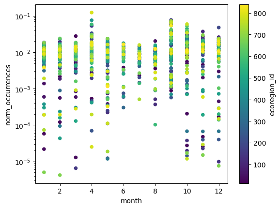

```python
# Plotting a scatter with normalized occurrences by month
occurrence_df.reset_index().plot.scatter(
    x='month', y='norm_occurrences', c='ecoregion_id', logy=True
)
```

**Figure 3:** Comparing this plot to the un-normalized occurrences, this data has a more clear horizonal cluster along the top of the graph (higher values). There is also a slight dip in the number of occurrences during the summer months, suggesting that the normalized version may be overcompensating for higher occurrences during the summer found in the raw data.

#### Plotting geographically

Next, we will prepare to plot the data geographically. This is a more effective way of interpreting the data.

```python
# Simplify the geometry to speed up processing
eco_gdf.geometry = eco_gdf.simplify(.1, preserve_topology=False)

# Change the CRS to Mercator for mapping
eco_gdf = eco_gdf.to_crs(ccrs.Mercator())

# Check that the plot runs in a reasonable amount of time
eco_gdf.hvplot(geo=True, crs=ccrs.Mercator())
```

#### Create an interactive plot of the migration data

Note: The plot will not display in the HTML version of this notebook.

```python
# Join the occurrences with the plotting GeoDataFrame
occurrence_gdf = eco_gdf.join(occurrence_df[['norm_occurrences']])

# Remove any empty geometry rows. These can cause errors if they persist in the data.
occurrence_gdf = occurrence_gdf[~occurrence_gdf.geometry.is_empty]

# Get the plot bounds so they don't change with the slider
# xmin, ymin, xmax, ymax = gbif_gdf.to_crs(ccrs.Mercator()).total_bounds

# This code above will plot the entire range of the data (even other continents/unusual sightings)
# I am just interested in the South-North American data, so I set the bounds manually.

xmin = -14821585.49397232
xmax = -4000000.0
ymax = 8826427.537488604
ymin = -1000000.0

# List month names on the slider
month_widget = pn.widgets.DiscreteSlider(
    options={
        calendar.month_name[month_num]: month_num
        for month_num in range(1,13)
    }
)

# Plot occurrence by ecoregion and month
migration_plot = (
    occurrence_gdf
    .hvplot(
        c='norm_occurrences',
        groupby='month',
        # Use background tiles
        geo=True, crs=ccrs.Mercator(), tiles='CartoLight',
        title="Baltimore Oriole Migration, 2024",
        xlim=(xmin, xmax), ylim=(ymin, ymax),
        frame_height=500,
        widgets={'month': month_widget},
        widget_location='bottom'
    )
)

# Save the plot
migration_plot.save('baltimore-oriole-migration.html', embed=True)
# Display the plot
migration_plot
```

```
WARNING:W-1005 (FIXED_SIZING_MODE): 'fixed' sizing mode requires width and height to be set: figure(id='p204203', ...)
```

```
BokehModel(combine_events=True, render_bundle={'docs_json': {'cd833894-6a91-45d1-ab89-a745994ab6d8': {'version…
```

**Results and Analysis:** According to the interative plot above, the Baltimore Oriole spends the coldest winter months (December/January) in warmer climates with ecoregions with dense observations in South and Central America. Surprisingly, there are also less dense ecoregions with Orioles along the East Coast of North America, extending into Canada during the coldest months. This suggests that while Orioles may prefer the warmer climates of the South, they can still tolorate the colder winter weather along the East Coast. There are also observations of Orioles on the Carribean islands in most months except for summer, suggesting that Orioles are very capable of migrating across fairly large water bodies.

During the summer months, Orioles are almost solely observed in the U.S. and Canada, and are almost completely absent from their winter habitats in Central and South America. Additionally, the Orioles range appears to be limited by the geographic barrier of the Rocky Mountains. This might be explained by the Oriole's habitat preferences which don't align well with the dense forests and steep terrain of the Rockies. However, the Oriole is not affraid to venture far north, with ecoregions with very dense summer observations found in the Northern U.S. and Canada.

These results align closely with maps and information provided by the [Cornell Lab of Ornithology](https://www.allaboutbirds.org/guide/Baltimore_Oriole/overview) and the [Audubon Society](https://www.audubon.org/field-guide/bird/baltimore-oriole).